# Inflation Drivers: Post-COVID Analysis

Week 1: An Inflation Primer

Riley Conlon

This page is a primer on the topic of inflation for my thesis, “Inflation Drivers: Post-COVID Analysis.”  
I have also decided to make the research notes I compile in the course of writing this thesis available as blog posts. This not only provides my advisor and committee with a way to follow my progress in near-real time, It creates content for a portfolio of work and, if I have done my job well, the general reader should walk away with a more sophisticated understanding of inflation.

## An Inflation Introduction

Inflation is defined simply as the “overall general upward price movement of goods and services”[^1] throughout the economy. That is, every time we see prices get marked up in our day-to-day lives, that is a specific example of inflation. If we were to take a weighted average of all of these increases, we would get a sense for how overall prices were changing in the economy.

### How is Inflation Measured?

The two most common[^2] ways inflation is measured is the Consumer Price Index (CPI) and the Personal Consumption Expenditure Price Index (PCE).
To create the CPI, every month employees at the Bureau of Labor Statistics survey several businesses and record the prices of various items. They take special care to collect data on the same items (controlling for weight, quantity and other variations), ensuring consistency across businesses and time periods[^3]. These prices don’t only become their own lines in the final report, but are also used to calculate price “baskets”.
For example, prices for beef and pork might be averaged to create a measurement for red meat. We can continue to aggregate by averaging meats and produce to get a measurement for groceries (called “food at home”). And at the highest aggregation level, we have the “All Items” basket, a weighted average designed to reflect the general changes in prices experienced by consumers from month to month.
It is worth noting that while all of this information is compiled from price data and baskets of goods, what is published is not the averages themselves. Instead, the indexed values, relative to some base period, are what is published.
$$CPI_t = \frac{(Basket Cost)_t}{(Basket Cost)_{Base}} \cdot 100$$
This is not a hindrance for us, because the nut of what we are interested in is the month-to-month rate:
$$\alpha_t = \frac{CPI_t}{CPI_{t-1}}$$
($\alpha_t$ is not typical notation, but we use it throughout this project for convenience.)

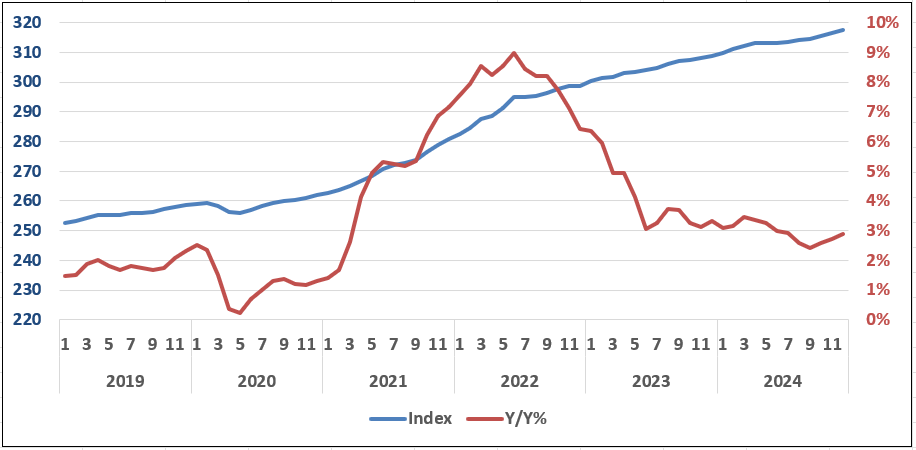

### Common Reporting & Moving Average

The most common way inflation is reported is by taking the year-over-year. That is, the percent increase between a given month and the same month in the prior year:
$$(Y/Y)_t = \frac{CPI_t}{CPI_{t-12}} - 1$$
Recalling our definition of $\alpha_t$ from the previous section, we can observe something insightful.
$$\begin{equation*}
\begin{split}
(Y/Y)_t &= (\frac{CPI_t}{CPI_{t-12}}) - 1 \\
&=
(\frac{CPI_t}{CPI_{t-1}})...(\frac{CPI_{t-11}}{CPI_{t-12}}) - 1 \\
&= (\alpha^{12}_t \cdot ... \cdot
\alpha^{12}_{t-11})^{1/12} - 1
\end{split}
\end{equation*}$$
That is, year-over-year is equivalent to the geometric mean of the annualized month-to-month rates.
Given this observation, we will consider both the year-over-year and month-to-month inflation rates throughout this project.

### Theoretical causes

We can illustrate the theoretical arguments for the causes of inflation by considering supply and demand. In figure 1, we show an economy in equilibrium with aggregate demand and short-term aggregate supply graphed over overall price on the vertical axis and total production on the horizontal axis. That is to say, what is produced finds buyers and no one feels like they would be better off doing something else.  
In figures 2 and 3, we can see how a supposed fall (left-shift) in supply or increase (right-shift) in demand results in a new equilibrium higher on the vertical axis. An upward movement here means inflation, which should match our intuition of the situation.  
This can provide a theoretical framework for assessing potential causes of inflation: if a proposed cause does not correspond with reduced supply or increased demand, then we should be suspicious.

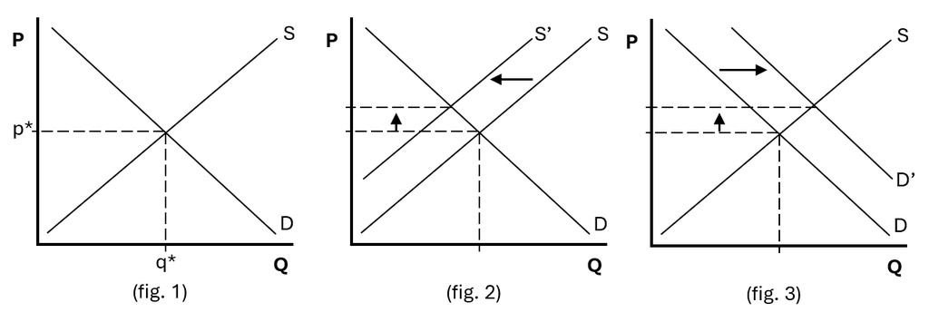

### A Terminology Note

It is worth keeping in mind that inflation is a rate of change. As shown in the illustration below, it is not uncommon to use the word “inflation” to refer to when prices are increasing at a consistent rate and when prices are increasing at an increasing rate. Throughout this project, we will try not to use the term “inflation” ambiguously.  
Continuing with the illustration, we can see when this rate is decelerating, but still positive, it is referred to as “disinflation”. When the rate is negative (sticker price decreasing), it is “deflation”.

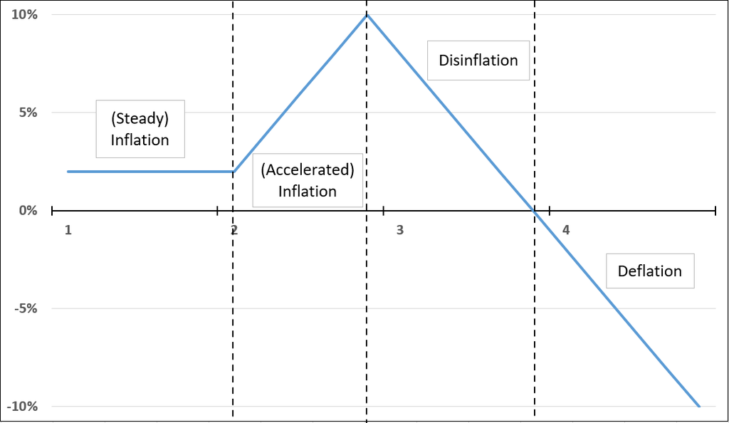

## Motivation for this research

The cause of the accelerated inflation that began in 2021 is quite controversial.

> The claim of price-gouging is simply not supported by the evidence, but it nonetheless erodes the faith in open markets that makes America prosperous.  
> The Economist (08/22/2024)[^4]

And yet, there has been less discussion of the cause of the comparably sudden disinflation seen roughly 18 months later

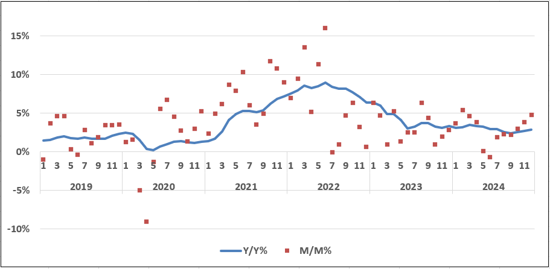

With the considerable social and economic consequences of accelerating inflation, one’s curiosity should not only be drawn to the cause of the increase, but also to the deceleration. A greater understanding of these causes would provide insight to the efficacy of past public policy and inform future policy.  
Thus the two goals of this project: evaluate the evidence for the proposed causes of the increased inflation and the subsequent disinflation. We also make the careful consideration that the causes may not be consistent for the full inflationary period, and that the causes of the increase may not be responsible for the decrease.  
(Author’s note: The “Background and Causes”[^5] section of the Wikipedia page for the 2021-2023 Inflation offers a considerable summary of the causes that we will be evaluating in this project.)  
In the next post we will analyze the sub-baskets of CPI and conduct a decomposition analysis. We will use those results to inform our further exploration.